# Latent Variable Model

We can use a dimension reduction technique to create correlation between stocks by building a covariance matrix with latent factor loading. That sounds complicated but is relatively straightforward to code. See `gllvm` for an R package that does that.

If we want the error for some stocks to be correlated, then for year $t$, across all stocks,

$$\boldsymbol{\epsilon}_t \sim N(\mathbf{0}, \Sigma),$$
where $\Sigma$ is a covariance matrix. We can induce a flexible low dimension covariance matrix by adding some unique random effects such that for some unobserved variables per year $z_t$, that capture the underlying factors driving stock abundance within each year, and factor loading $\boldsymbol{\lambda}_s$ per stock,

$$\mathbf{z}_i \sim N(\mathbf{0}, \text{I}).$$
We will start with two latent variables, and write

$$\log(R_i/S_i) = \alpha_{s_i} + \beta_{s_i} S_i + \mathbf{z}_{t_i}\cdot\boldsymbol{\lambda}_{s_i} + \epsilon_i.$$

Fitting this model gives the residual covariance matrix,

$$\Sigma = \boldsymbol{\lambda} \boldsymbol{\lambda}^T + \text{diag}(\sigma^2_j).$$
Positive covariance indicates where the stocks tend to vary similarly each year, and negative would be stocks that perform differently.

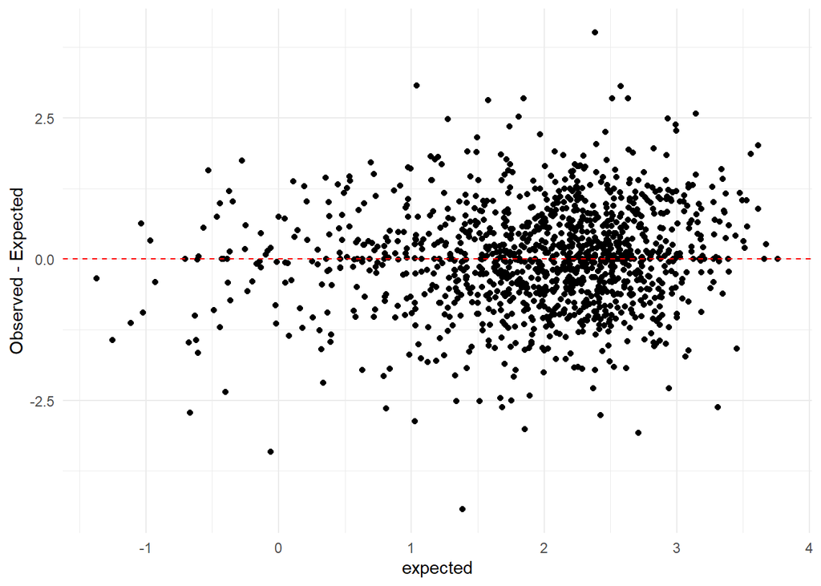

```r
library(RTMB)

## Remove Harrison and Cultus?
# sox <- sox %>% filter(!PopName %in% c("Harrison", "Cultus"))

sox$stock <- as.numeric(factor(sox$PopName))
nstocks <- max(sox$stock)
sox <- sox %>% mutate(time = yr - min(yr) + 1)
nyears <- max(sox$time)
minyear <- min(sox$yr)
sox$logRS <- log(sox$recruits/sox$spawners)
nobs <- nrow(sox)

parameters <- list(
  alpha0 = runif(1, 2, 5),
  re = rnorm(nstocks),
  logbeta = runif(nstocks, 0, 1),
  logsigma = runif(nstocks, 3, 5),
  logsigma_re = runif(1, 0.5, 2),
  re_time = rnorm(nyears),
  logitphi = 0,
  logsigma_time = 0,
  z = matrix(0, nrow = nyears, ncol = 2),
  logscale_z = c(0,0),
  lambda1 = c(1, rnorm(nstocks-1)),
  lambda2 = c(0,1, rnorm(nstocks-2))
)

negll <- function(pars){

  getAll(pars, sox, warn = FALSE)
  beta <- exp(logbeta)

  logRS <- OBS(logRS)

  sigma <- exp(logsigma)
  sigma_re <- exp(logsigma_re)
  sigma_time <- exp(logsigma_time)
  sigma_obs <- sigma[stock]
  scale_z <- exp(logscale_z)
  phi <- 2*plogis(logitphi)-1

  alpha_stock <- re + alpha0
  ADREPORT(alpha_stock)

  mu <- AD(numeric(nobs))
  for( i in 1:nobs ){
    mu[i] <- alpha_stock[stock[i]] + re_time[time[i]] - beta[stock[i]]*spawners_scaled[i] +
      z[time[i],1]*lambda1[stock[i]]*scale_z[1] + z[time[i],2]*lambda2[stock[i]]*scale_z[2]
  }

  ## Use this for built in residuals
  ll <- dautoreg(re_time,phi=phi,scale=sqrt(sigma_time^2/(1-phi^2)), log=TRUE)
  ## Add in latent variables
  for( i in 1:2 ) ll <- ll + sum(dnorm(z[,i], 0, 1, log = TRUE))


  ll <- ll + sum(dnorm(re, 0, sigma_re, log = TRUE))
  ll <- ll + sum(dnorm(logRS, mu, sigma_obs, log = TRUE))

  REPORT(mu)
  REPORT(re_time)
  REPORT(sigma_obs)

  return(-ll)
}

obj <- MakeADFun(func = negll, parameters = parameters, random = c("re", "re_time", "z"),
  map = list(lambda1 = factor(c(NA, 2:nstocks)), lambda2 = factor(c(NA, NA, 3:nstocks))),
  silent = TRUE)
fit <- nlminb(obj$par, obj$fn, obj$gr)
sox$expected <- obj$report()$mu
sox$sigma <- obj$report()$sigma_obs
re_time <- obj$report()$re_time

sox <- sox %>%
  mutate(resid = logRS - expected) %>%
  mutate(resid_std = resid/sigma)

ggplot(data = sox, aes(x = expected, y = resid_std)) +
  geom_point() + theme_minimal() +
  geom_hline(yintercept = 0, col = 'red', linetype = 2) +
  ylab("Observed - Expected")
```

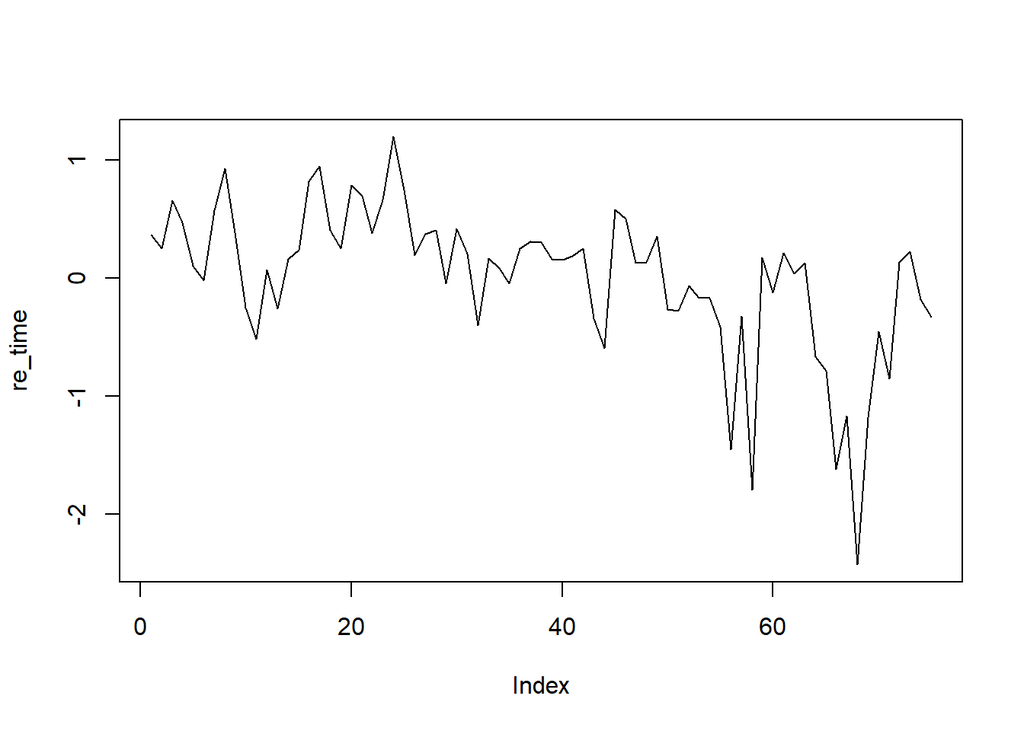

```r
plot(re_time, type = 'l')
```

By fitting a covariance matrix between stocks, we can use that to cluster them into stocks based on similarity in response each year.

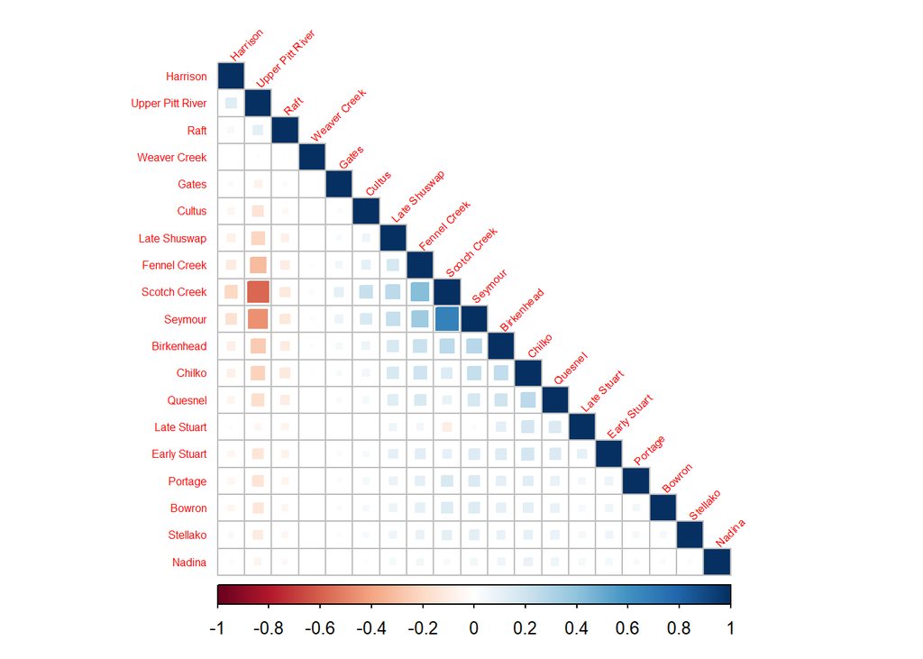

```r
## Stock Covariance
## Extract fitted parameters as a list
pList <- obj$env$parList(fit$par)

## Factor loading matrix
Lambda <- cbind(pList$lambda1*exp(pList$logscale[1]),
  pList$lambda2*pList$lambda1*exp(pList$logscale[2]))
sigma <- exp(pList$logsigma)


## Covariance between stocks
Sigma_latent <- Lambda %*% t(Lambda) + diag(sigma^2)
stock_names <- sox %>% select(stock, PopName, MU) %>% distinct() %>% arrange(stock)
colnames(Sigma_latent) <- stock_names$PopName
rownames(Sigma_latent) <- stock_names$PopName

library(corrplot); library(gclus);
Cor_latent <- cov2cor(Sigma_latent)
Cor_latent_ord <- Cor_latent[order.single(Cor_latent), order.single(Cor_latent)]

corrplot(Cor_latent_ord, diag = TRUE, type = "lower",
         method = "square", tl.cex = 0.5, tl.srt = 45, tl.col = "red")
```

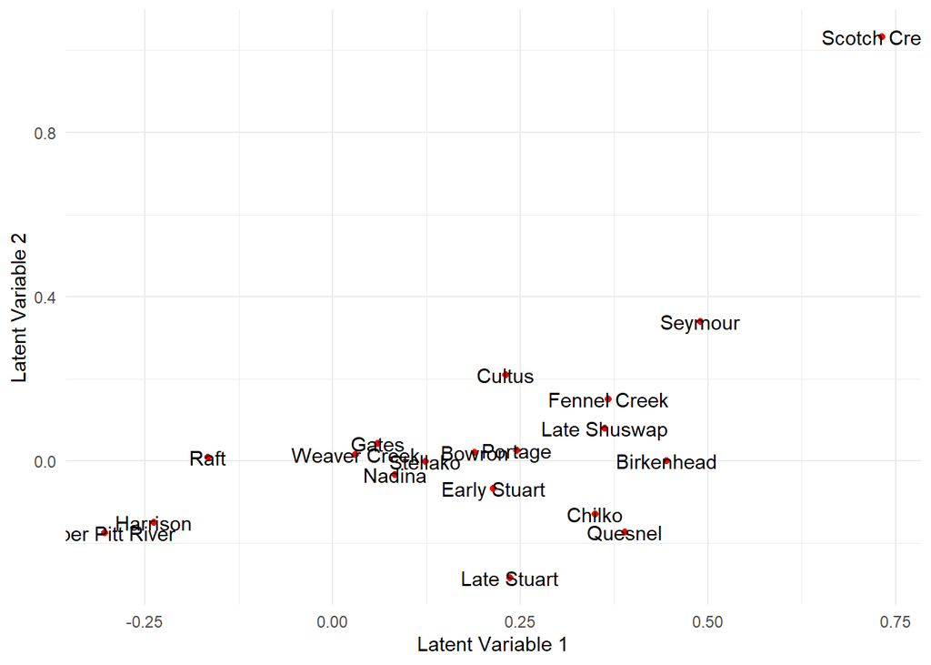

```r
colnames(Lambda) <- c("lambda_1", "lambda_2")
stock_names <- cbind(stock_names, Lambda)
stock_names$sigma <- sigma

ggplot(stock_names, aes(x = lambda_1, y = lambda_2)) + geom_point(colour = "red") +
  theme_minimal() + xlab("Latent Variable 1") + ylab("Latent Variable 2") +
  geom_text(aes(label = PopName))
```

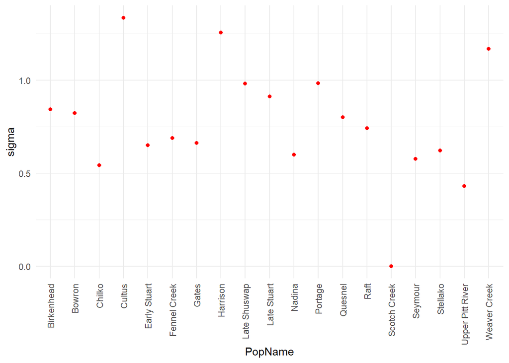

```r
ggplot(stock_names, aes(x = PopName, y = sigma)) + geom_point(colour = "red") +
  theme_minimal() +
  theme(axis.text.x = element_text(angle = 90, vjust = 0.5, hjust = 1))
```

Main problem with this model is that Scotch Creek variability is almost zero. Very suspicious. Residuals are almost zero. Likely overparameterized. Maybe penalizing the factor loading will help simplify it.

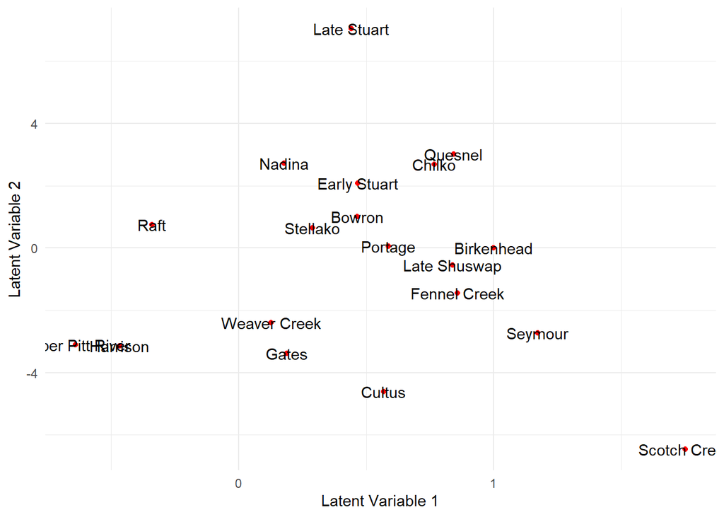

```r
parameters <- list(
  alpha0 = runif(1, 2, 5),
  re = rnorm(nstocks),
  logbeta = runif(nstocks, 0, 1),
  logsigma = runif(nstocks, 3, 5),
  logsigma_re = runif(1, 0.5, 2),
  re_time = rnorm(nyears),
  logitphi = 0,
  logsigma_time = 0,
  z = matrix(0, nrow = nyears, ncol = 2),
  logscale_z = c(0,0),
  lambda1 = c(1, rnorm(nstocks-1)),
  lambda2 = c(0,1, rnorm(nstocks-2)),
  logpen = 0
)

negll <- function(pars){

  getAll(pars, sox, warn = FALSE)
  beta <- exp(logbeta)

  logRS <- OBS(logRS)
  pen <- exp(logpen)
  sigma <- exp(logsigma)
  sigma_re <- exp(logsigma_re)
  sigma_time <- exp(logsigma_time)
  sigma_obs <- sigma[stock]
  scale_z <- exp(logscale_z)
  phi <- 2*plogis(logitphi)-1

  alpha_stock <- re + alpha0
  ADREPORT(alpha_stock)

  mu <- AD(numeric(nobs))
  for( i in 1:nobs ){
    mu[i] <- alpha_stock[stock[i]] + re_time[time[i]] - beta[stock[i]]*spawners_scaled[i] +
      z[time[i],1]*lambda1[stock[i]]*scale_z[1] + z[time[i],2]*lambda2[stock[i]]*scale_z[2]
  }

  ## Use this for built in residuals
  ll <- dautoreg(re_time,phi=phi,scale=sqrt(sigma_time^2/(1-phi^2)), log=TRUE)
  ## Add in latent variables
  for( i in 1:2 ) ll <- ll + sum(dnorm(z[,i], 0, 1, log = TRUE))


  ll <- ll + sum(dnorm(re, 0, sigma_re, log = TRUE))
  ll <- ll + sum(dnorm(logRS, mu, sigma_obs, log = TRUE))

  REPORT(mu)
  REPORT(re_time)
  REPORT(sigma_obs)

  return(-ll + pen/2*sum(lambda1^2 + lambda2^2))
}

obj <- MakeADFun(func = negll, parameters = parameters, random = c("re", "re_time", "z"),
  map = list(lambda1 = factor(c(NA, 2:nstocks)), lambda2 = factor(c(NA, NA, 3:nstocks))),
  silent = TRUE)
fit <- nlminb(obj$par, obj$fn, obj$gr)
sox$expected <- obj$report()$mu
sox$sigma <- obj$report()$sigma_obs
re_time <- obj$report()$re_time

pList <- obj$env$parList(fit$par)
stock_names$lambda_1 <- pList$lambda1
stock_names$lambda_2 <- pList$lambda2
stock_names$sigma <- exp(pList$logsigma)

ggplot(stock_names, aes(x = lambda_1, y = lambda_2)) + geom_point(colour = "red") +
  theme_minimal() + xlab("Latent Variable 1") + ylab("Latent Variable 2") +
  geom_text(aes(label = PopName))
```

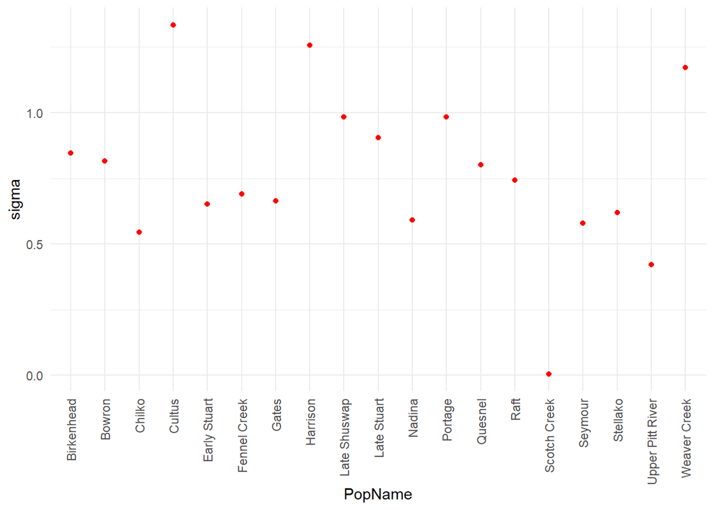

```r
ggplot(stock_names, aes(x = PopName, y = sigma)) + geom_point(colour = "red") +
  theme_minimal() +
  theme(axis.text.x = element_text(angle = 90, vjust = 0.5, hjust = 1))
```